# Untitled

Katina OLODO

11/13/2023

## Data Importation and checking

```r
library(readxl)
library(dplyr)
Data <- read_excel("C:/After thesis/Consultation/DENGUE FEVER/Data.xlsx",na="NA")
dim(Data)
```

```
## [1] 5633   29
```

```r
Data$Age=as.numeric(Data$Age)
Data[,3:29] <- lapply(Data[,3:29], factor)
str(Data)
```

```
## tibble [5,633 x 29] (S3: tbl_df/tbl/data.frame)
##  $ ID                : chr [1:5633] "A- D1" "A- D2" "A- D3" "A- D4" ...
##  $ Age               : num [1:5633] 28 14 65 60 21 50 45 33 39 19 ...
##  $ GroupAge          : Factor w/ 3 levels "Above50","Between18-49",..: 2 3 1 1 2 1 2 2 2 2 ...
##  $ Gender            : Factor w/ 2 levels "Female","Male": 2 2 2 1 2 2 2 2 1 2 ...
##  $ District          : Factor w/ 20 levels "IISB","ISAB",..: 4 10 10 10 4 10 4 4 4 10 ...
##  $ NS1               : Factor w/ 2 levels "HS1","null": 1 1 2 1 1 1 1 1 1 1 ...
##  $ IgM               : Factor w/ 2 levels "LgM","null": 2 2 2 1 1 1 1 1 1 1 ...
##  $ IgG               : Factor w/ 2 levels "LgG","null": 2 2 2 1 1 1 1 1 1 2 ...
##  $ DF                : Factor w/ 2 levels "DF","null": 2 1 1 1 1 2 2 2 2 1 ...
##  $ DHF               : Factor w/ 2 levels "DHF","null": 1 1 1 2 1 1 1 1 1 2 ...
##  $ DSS               : Factor w/ 2 levels "DSS","null": 2 2 2 2 1 2 2 2 2 2 ...
##  $ Fever(>38 C)      : Factor w/ 2 levels "No","Yes": 2 2 2 2 2 2 2 2 2 2 ...
##  $ Myalgia           : Factor w/ 2 levels "No","Yes": 2 2 2 2 1 1 2 2 1 2 ...
##  $ Arthralgia        : Factor w/ 2 levels "No","Yes": 2 2 1 1 2 2 2 2 1 2 ...
##  $ Erythema          : Factor w/ 2 levels "No","Yes": 1 1 1 1 1 1 1 1 1 1 ...
##  $ Facial flushing   : Factor w/ 2 levels "No","Yes": 1 1 1 1 1 1 1 1 1 1 ...
##  $ Retro-orbital pain: Factor w/ 2 levels "No","Yes": 1 2 1 2 1 2 1 1 1 2 ...
##  $ Nausea            : Factor w/ 2 levels "No","Yes": 1 1 1 1 1 1 1 1 1 1 ...
##  $ Vomiting          : Factor w/ 2 levels "No","Yes": 2 1 1 1 2 1 1 2 1 1 ...
##  $ Diarrhea          : Factor w/ 2 levels "No","Yes": 1 1 1 1 2 1 1 1 1 1 ...
##  $ Abdominal Pain    : Factor w/ 2 levels "No","Yes": 2 1 1 1 1 1 1 2 1 1 ...
##  $ Rash              : Factor w/ 2 levels "No","Yes": 1 1 1 2 1 1 1 1 2 1 ...
##  $ Diabets           : Factor w/ 2 levels "No","Yes": 1 1 1 2 1 1 1 1 2 1 ...
##  $ Pregnancy         : Factor w/ 2 levels "No","Yes": 1 1 1 2 1 1 1 1 2 1 ...
##  $ Petic Ulcer       : Factor w/ 2 levels "No","Yes": 1 1 1 1 1 1 1 1 1 1 ...
##  $ Liver Disease     : Factor w/ 2 levels "No","Yes": 1 1 2 2 1 1 1 1 1 1 ...
##  $ Hypertension      : Factor w/ 2 levels "No","YES": 1 1 1 1 1 1 1 1 1 1 ...
##  $ Infancy/ Old age  : Factor w/ 2 levels "No","Yes": 1 1 1 1 1 1 1 1 1 1 ...
##  $ Renal disease     : Factor w/ 2 levels "No","Yes": 1 1 1 1 1 1 1 1 1 1 ...
```

```r
Data$grpage <- cut(Data$Age, c(0,10,18,25,50,75,100), right = FALSE, include.lowest = TRUE)# to create class for age
```

## Does gender associate with serology (NS1,IgM,IgG) and with Diagnosis (DF,DHF, DSS)?

```
  -I found there is a significant association between gender and  NS1 *(Male patient seems to have more HS1 than woman)*
   -I found there is a significant association between gender and DSS
  - No association between Gender and IgM and IgG
  - No association between Gender and DF and DHF
```

```r
library(gplots)
# NS1
round((table(Data$Gender,Data$NS1)/5980)*100,2)# percentage
```

```
##
##            HS1  null
##   Female 21.29  3.85
##   Male   59.58  8.41
```

```r
chisq.test(table(Data$Gender,Data$NS1))
```

```
##
##  Pearson's Chi-squared test with Yates' continuity correction
##
## data:  table(Data$Gender, Data$NS1)
## X-squared = 7.9982, df = 1, p-value = 0.004682
```

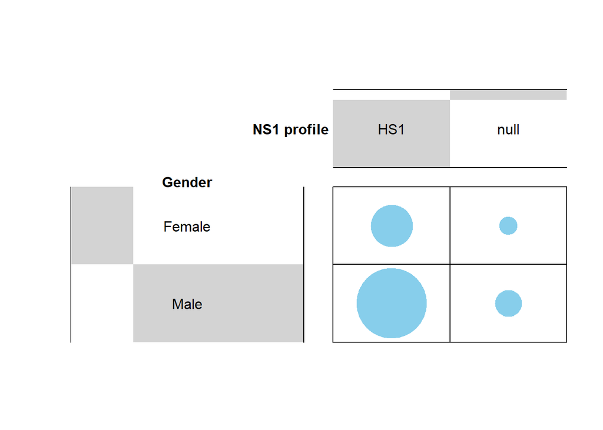

```r
## Graph
balloonplot(t(table(Data$Gender,Data$NS1)), main ="", xlab ="NS1 profile", ylab="Gender",label = FALSE, show.margins = FALSE)
```

```r
# IgM
round((table(Data$Gender,Data$IgM)/5980)*100,2)# percentage
```

```
##
##            LgM  null
##   Female 10.87 14.26
##   Male   28.78 39.21
```

```r
chisq.test(table(Data$Gender,Data$IgM))
```

```
##
##  Pearson's Chi-squared test with Yates' continuity correction
##
## data:  table(Data$Gender, Data$IgM)
## X-squared = 0.34338, df = 1, p-value = 0.5579
```

```r
# IgG
round((table(Data$Gender,Data$IgG)/5980)*100,2)# percentage
```

```
##
##            LgG  null
##   Female 10.10 15.03
##   Male   25.43 42.56
```

```r
chisq.test(table(Data$Gender,Data$IgG))
```

```
##
##  Pearson's Chi-squared test with Yates' continuity correction
##
## data:  table(Data$Gender, Data$IgG)
## X-squared = 3.4733, df = 1, p-value = 0.06237
```

```r
# DF
round((table(Data$Gender,Data$DF)/5980)*100,2)# percentage
```

```
##
##             DF  null
##   Female 11.29 13.83
##   Male   32.32 35.67
```

```r
chisq.test(table(Data$Gender,Data$DF))
```

```
##
##  Pearson's Chi-squared test with Yates' continuity correction
##
## data:  table(Data$Gender, Data$DF)
## X-squared = 2.8753, df = 1, p-value = 0.08995
```

```r
#DHF
round((table(Data$Gender,Data$DHF)/5980)*100,2)# percentage
```

```
##
##            DHF  null
##   Female 12.46 12.68
##   Male   33.41 34.58
```

```r
chisq.test(table(Data$Gender,Data$DHF))
```

```
##
##  Pearson's Chi-squared test with Yates' continuity correction
##
## data:  table(Data$Gender, Data$DHF)
## X-squared = 0.064323, df = 1, p-value = 0.7998
```

```r
#DSS
round((table(Data$Gender,Data$DSS)/5980)*100,2)# percentage
```

```
##
##            DSS  null
##   Female  1.05 24.06
##   Male    1.81 66.19
```

```r
chisq.test(table(Data$Gender,Data$DSS))
```

```
##
##  Pearson's Chi-squared test with Yates' continuity correction
##
## data:  table(Data$Gender, Data$DSS)
## X-squared = 8.2092, df = 1, p-value = 0.004168
```

## Does Age group associate with serology (NS1,IgM,IgG) and with Diagnosis (DF,DHF, DSS)?

[output not shown]

```r
# i use the groupe age with 3 factors here
# NS1
round((table(Data$GroupAge,Data$NS1)/5980)*100,2)# percentage
```

```
##
##                  HS1  null
##   Above50      12.12  1.74
##   Between18-49 58.55  8.90
##   Under18      10.48  1.59
```

```r
chisq.test(table(Data$GroupAge,Data$NS1))
```

```
##
##  Pearson's Chi-squared test
##
## data:  table(Data$GroupAge, Data$NS1)
## X-squared = 0.25544, df = 2, p-value = 0.8801
```

```r
# IgM
round((table(Data$GroupAge,Data$IgM)/5980)*100,2)# percentage
```

```
##
##                  LgM  null
##   Above50       5.43  8.43
##   Between18-49 28.60 38.85
##   Under18       5.67  6.40
```

```r
chisq.test(table(Data$GroupAge,Data$IgM))
```

```
##
##  Pearson's Chi-squared test
##
## data:  table(Data$GroupAge, Data$IgM)
## X-squared = 9.559, df = 2, p-value = 0.0084
```

```r
# IgG
round((table(Data$GroupAge,Data$IgG)/5980)*100,2)# percentage
```

```
##
##                  LgG  null
##   Above50       6.19  7.68
##   Between18-49 25.18 42.26
##   Under18       4.15  7.93
```

```r
chisq.test(table(Data$GroupAge,Data$IgG))
```

```
##
##  Pearson's Chi-squared test
##
## data:  table(Data$GroupAge, Data$IgG)
## X-squared = 20.292, df = 2, p-value = 3.923e-05
```

```r
# DF
round((table(Data$GroupAge,Data$DF)/5980)*100,2)# percentage
```

```
##
##                   DF  null
##   Above50       6.27  7.58
##   Between18-49 31.82 35.62
##   Under18       5.60  6.47
```

```r
chisq.test(table(Data$GroupAge,Data$DF))
```

```
##
##  Pearson's Chi-squared test
##
## data:  table(Data$GroupAge, Data$DF)
## X-squared = 1.046, df = 2, p-value = 0.5927
```

```r
#DHF
round((table(Data$GroupAge,Data$DHF)/5980)*100,2)# percentage
```

```
##
##                  DHF  null
##   Above50       7.02  6.84
##   Between18-49 33.39 34.05
##   Under18       5.55  6.52
```

```r
chisq.test(table(Data$GroupAge,Data$DHF))
```

```
##
##  Pearson's Chi-squared test
##
## data:  table(Data$GroupAge, Data$DHF)
## X-squared = 3.8588, df = 2, p-value = 0.1452
```

```r
#DSS
round((table(Data$GroupAge,Data$DSS)/5980)*100,2)# percentage
```

```
##
##                  DSS  null
##   Above50       0.30 13.55
##   Between18-49  1.76 65.69
##   Under18       0.79 11.29
```

```r
chisq.test(table(Data$GroupAge,Data$DSS))
```

```
##
##  Pearson's Chi-squared test
##
## data:  table(Data$GroupAge, Data$DSS)
## X-squared = 34.148, df = 2, p-value = 3.845e-08
```

## Does district associate with Diagnosis(DF,DHF, DSS)?

Here i want to know if they have any tendency in your data, high prevalence for some district. I don’t have any association

```r
# DF
round((table(Data$District,Data$DF)/5980)*100,2)# percentage
```

```
##
##                            DF  null
##   IISB                   0.02  0.02
##   ISAB                   0.02  0.00
##   ISD                    0.02  0.00
##   Islamabad             17.63 19.70
##   ISLAMBAD               0.02  0.00
##   KURI ROAD              0.02  0.00
##   MODEL TOWN Islamabad   0.00  0.02
##   MUSLIMABAD Rawalpindi  0.02  0.00
##   RAWALPIND              0.00  0.03
##   Rawalpindi            26.29 30.20
##   Rawalpindi[            0.02  0.02
##   Rawalpindi`            0.02  0.00
##   RawalpindiV            0.02  0.00
##   RAWALPINID             0.00  0.02
##   RAWAPINDI              0.00  0.02
##   RAWAT                  0.02  0.02
##   RAWAT Rawalpindi       0.02  0.00
##   TAXILA                 0.00  0.02
##   TOWN Rawalpindi        0.02  0.00
##   WAH CANTT              0.00  0.02
```

```r
chisq.test(table(Data$District,Data$DF))# khi test for quick analysis
```

```
##
##  Pearson's Chi-squared test
##
## data:  table(Data$District, Data$DF)
## X-squared = 16.662, df = 19, p-value = 0.6127
```

```r
# DHF
round((table(Data$District,Data$DHF)/5980)*100,2)# percentage
```

```
##
##                           DHF  null
##   IISB                   0.02  0.02
##   ISAB                   0.00  0.02
##   ISD                    0.00  0.02
##   Islamabad             18.33 19.00
##   ISLAMBAD               0.02  0.00
##   KURI ROAD              0.00  0.02
##   MODEL TOWN Islamabad   0.02  0.00
##   MUSLIMABAD Rawalpindi  0.00  0.02
##   RAWALPIND              0.02  0.02
##   Rawalpindi            27.83 28.68
##   Rawalpindi[            0.02  0.02
##   Rawalpindi`            0.00  0.02
##   RawalpindiV            0.00  0.02
##   RAWALPINID             0.02  0.00
##   RAWAPINDI              0.02  0.00
##   RAWAT                  0.02  0.02
##   RAWAT Rawalpindi       0.00  0.02
##   TAXILA                 0.02  0.00
##   TOWN Rawalpindi        0.00  0.02
##   WAH CANTT              0.02  0.00
```

```r
chisq.test(table(Data$District,Data$DHF))
```

```
##
##  Pearson's Chi-squared test
##
## data:  table(Data$District, Data$DHF)
## X-squared = 13.955, df = 19, p-value = 0.7863
```

```r
# DSS
round((table(Data$District,Data$DSS)/5980)*100,2)# percentage
```

```
##
##                           DSS  null
##   IISB                   0.00  0.03
##   ISAB                   0.00  0.02
##   ISD                    0.00  0.02
##   Islamabad              1.24 36.09
##   ISLAMBAD               0.00  0.02
##   KURI ROAD              0.00  0.02
##   MODEL TOWN Islamabad   0.00  0.02
##   MUSLIMABAD Rawalpindi  0.00  0.02
##   RAWALPIND              0.00  0.03
##   Rawalpindi             1.66 54.83
##   Rawalpindi[            0.00  0.03
##   Rawalpindi`            0.00  0.02
##   RawalpindiV            0.00  0.02
##   RAWALPINID             0.00  0.02
##   RAWAPINDI              0.00  0.02
##   RAWAT                  0.00  0.03
##   RAWAT Rawalpindi       0.00  0.02
##   TAXILA                 0.00  0.02
##   TOWN Rawalpindi        0.00  0.02
##   WAH CANTT              0.00  0.02
```

```r
chisq.test(table(Data$District,Data$DSS))
```

```
##
##  Pearson's Chi-squared test
##
## data:  table(Data$District, Data$DSS)
## X-squared = 1.3679, df = 19, p-value = 1
```

## Does gender, Age, group-age, and district infuence the fact to contract DF?

I found that only groupeage influence DF.. For instance grpage[18,25) and grpage[75,100] are more succeptible for DF than other group age.

```r
library(car)
round((table(Data$grpage,Data$DF)/5980)*100,2)# percentage
```

```
##
##               DF  null
##   [0,10)    0.79  1.09
##   [10,18)   4.82  5.38
##   [18,25)  10.33  9.08
##   [25,50)  21.49 26.54
##   [50,75)   5.79  7.27
##   [75,100]  0.48  0.30
```

```r
Data$DF <- relevel(Data$DF, "null")
levels(Data$DF)# DF is variable i want to explain
```

```
## [1] "null" "DF"
```

```r
levels(Data$Gender)
```

```
## [1] "Female" "Male"
```

```r
levels(Data$grpage)
```

```
## [1] "[0,10)"   "[10,18)"  "[18,25)"  "[25,50)"  "[50,75)"  "[75,100]"
```

```r
levels(Data$District)
```

```
##  [1] "IISB"                  "ISAB"                  "ISD"
##  [4] "Islamabad"             "ISLAMBAD"              "KURI ROAD"
##  [7] "MODEL TOWN Islamabad"  "MUSLIMABAD Rawalpindi" "RAWALPIND"
## [10] "Rawalpindi"            "Rawalpindi["           "Rawalpindi`"
## [13] "RawalpindiV"           "RAWALPINID"            "RAWAPINDI"
## [16] "RAWAT"                 "RAWAT Rawalpindi"      "TAXILA"
## [19] "TOWN Rawalpindi"       "WAH CANTT"
```

```r
reg <- glm(DF ~ Gender + grpage + District, data = Data, family = binomial(logit))
reg
```

```
##
## Call:  glm(formula = DF ~ Gender + grpage + District, family = binomial(logit),
##     data = Data)
##
## Coefficients:
##                   (Intercept)                     GenderMale
##                     -0.183559                       0.079326
##                 grpage[10,18)                  grpage[18,25)
##                      0.206793                       0.439946
##                 grpage[25,50)                  grpage[50,75)
##                      0.105537                       0.102927
##                grpage[75,100]                   DistrictISAB
##                      0.803498                      13.644088
##                   DistrictISD              DistrictIslamabad
##                     13.230352                      -0.175277
##              DistrictISLAMBAD              DistrictKURI ROAD
##                     13.564762                      13.644088
##  DistrictMODEL TOWN Islamabad  DistrictMUSLIMABAD Rawalpindi
##                    -13.488045                      13.564762
##             DistrictRAWALPIND             DistrictRawalpindi
##                    -13.566067                      -0.205986
##           DistrictRawalpindi[            DistrictRawalpindi`
##                     -0.001305                      13.644088
##           DistrictRawalpindiV             DistrictRAWALPINID
##                     13.567371                     -13.567371
##             DistrictRAWAPINDI                  DistrictRAWAT
##                    -13.901781                      -0.128846
##      DistrictRAWAT Rawalpindi                 DistrictTAXILA
##                     13.567371                     -13.589301
##       DistrictTOWN Rawalpindi              DistrictWAH CANTT
##                     13.564762                     -13.668628
##
## Degrees of Freedom: 5521 Total (i.e. Null);  5496 Residual
##   (111 observations deleted due to missingness)
## Null Deviance:       7633
## Residual Deviance: 7577  AIC: 7629
```

```r
summary(reg)
```

```
##
## Call:
## glm(formula = DF ~ Gender + grpage + District, family = binomial(logit),
##     data = Data)
##
## Deviance Residuals:
##    Min      1Q  Median      3Q     Max
## -1.406  -1.103  -1.059   1.252   1.347
##
## Coefficients:
##                                 Estimate Std. Error z value Pr(>|z|)
## (Intercept)                    -0.183559   1.428992  -0.128   0.8978
## GenderMale                      0.079326   0.061702   1.286   0.1986
## grpage[10,18)                   0.206793   0.210008   0.985   0.3248
## grpage[18,25)                   0.439946   0.202613   2.171   0.0299 *
## grpage[25,50)                   0.105537   0.197183   0.535   0.5925
## grpage[50,75)                   0.102927   0.206633   0.498   0.6184
## grpage[75,100]                  0.803498   0.357093   2.250   0.0244 *
## DistrictISAB                   13.644088 535.413041   0.025   0.9797
## DistrictISD                    13.230352 535.413041   0.025   0.9803
## DistrictIslamabad              -0.175277   1.415299  -0.124   0.9014
## DistrictISLAMBAD               13.564762 535.413038   0.025   0.9798
## DistrictKURI ROAD              13.644088 535.413041   0.025   0.9797
## DistrictMODEL TOWN Islamabad  -13.488045 535.413041  -0.025   0.9799
## DistrictMUSLIMABAD Rawalpindi  13.564762 535.413038   0.025   0.9798
## DistrictRAWALPIND             -13.566067 378.595361  -0.036   0.9714
## DistrictRawalpindi             -0.205986   1.415099  -0.146   0.8843
## DistrictRawalpindi[            -0.001305   2.000420  -0.001   0.9995
## DistrictRawalpindi`            13.644088 535.413041   0.025   0.9797
## DistrictRawalpindiV            13.567371 535.413038   0.025   0.9798
## DistrictRAWALPINID            -13.567371 535.413038  -0.025   0.9798
## DistrictRAWAPINDI             -13.901781 535.413041  -0.026   0.9793
## DistrictRAWAT                  -0.128846   2.006202  -0.064   0.9488
## DistrictRAWAT Rawalpindi       13.567371 535.413038   0.025   0.9798
## DistrictTAXILA                -13.589301 535.413047  -0.025   0.9798
## DistrictTOWN Rawalpindi        13.564762 535.413038   0.025   0.9798
## DistrictWAH CANTT             -13.668628 535.413044  -0.026   0.9796
## ---
## Signif. codes:  0 '***' 0.001 '**' 0.01 '*' 0.05 '.' 0.1 ' ' 1
##
## (Dispersion parameter for binomial family taken to be 1)
##
##     Null deviance: 7632.7  on 5521  degrees of freedom
## Residual deviance: 7577.4  on 5496  degrees of freedom
##   (111 observations deleted due to missingness)
## AIC: 7629.4
##
## Number of Fisher Scoring iterations: 12
```

```r
Anova(reg)## to know wich variable seem to influence DF
```

|  | LR Chisq | Df | Pr(>Chisq) |
| --- | --- | --- | --- |
| Gender | 1.654622 | 1 | 1.983310e-01 |
| grpage | 29.524217 | 5 | 1.829471e-05 |
| District | 23.347102 | 19 | 2.223992e-01 |

## Does gender, Age, group-age, and district infuence the fact to contract DHF?

Here also age have an influence, but interpretation are more difficult for me as, logistic regression doesn’t confirm

```r
round((table(Data$grpage,Data$DHF)/5980)*100,2)
```

```
##
##              DHF  null
##   [0,10)    0.90  0.97
##   [10,18)   4.65  5.55
##   [18,25)   8.55 10.87
##   [25,50)  24.85 23.18
##   [50,75)   6.71  6.35
##   [75,100]  0.32  0.48
```

```r
Data$DHF <- relevel(Data$DHF, "null")
levels(Data$DHF)# DHF is variable i want to explain
```

```
## [1] "null" "DHF"
```

```r
levels(Data$Gender)
```

```
## [1] "Female" "Male"
```

```r
levels(Data$grpage)
```

```
## [1] "[0,10)"   "[10,18)"  "[18,25)"  "[25,50)"  "[50,75)"  "[75,100]"
```

```r
levels(Data$District)
```

```
##  [1] "IISB"                  "ISAB"                  "ISD"
##  [4] "Islamabad"             "ISLAMBAD"              "KURI ROAD"
##  [7] "MODEL TOWN Islamabad"  "MUSLIMABAD Rawalpindi" "RAWALPIND"
## [10] "Rawalpindi"            "Rawalpindi["           "Rawalpindi`"
## [13] "RawalpindiV"           "RAWALPINID"            "RAWAPINDI"
## [16] "RAWAT"                 "RAWAT Rawalpindi"      "TAXILA"
## [19] "TOWN Rawalpindi"       "WAH CANTT"
```

```r
reg <- glm(DHF ~ Gender + grpage + District, data = Data, family = binomial(logit))
reg
```

```
##
## Call:  glm(formula = DHF ~ Gender + grpage + District, family = binomial(logit),
##     data = Data)
##
## Coefficients:
##                   (Intercept)                     GenderMale
##                    -1.308e-01                     -3.995e-03
##                 grpage[10,18)                  grpage[18,25)
##                    -9.727e-02                     -1.624e-01
##                 grpage[25,50)                  grpage[50,75)
##                     1.469e-01                      1.226e-01
##                grpage[75,100]                   DistrictISAB
##                    -3.507e-01                     -1.358e+01
##                   DistrictISD              DistrictIslamabad
##                    -1.327e+01                      5.523e-02
##              DistrictISLAMBAD              DistrictKURI ROAD
##                     1.355e+01                     -1.358e+01
##  DistrictMODEL TOWN Islamabad  DistrictMUSLIMABAD Rawalpindi
##                     1.355e+01                     -1.358e+01
##             DistrictRAWALPIND             DistrictRawalpindi
##                     6.025e-14                      6.377e-02
##           DistrictRawalpindi[            DistrictRawalpindi`
##                    -1.216e-02                     -1.358e+01
##           DistrictRawalpindiV             DistrictRAWALPINID
##                    -1.355e+01                      1.355e+01
##             DistrictRAWAPINDI                  DistrictRAWAT
##                     1.386e+01                      1.405e-01
##      DistrictRAWAT Rawalpindi                 DistrictTAXILA
##                    -1.355e+01                      1.379e+01
##       DistrictTOWN Rawalpindi              DistrictWAH CANTT
##                    -1.358e+01                      1.380e+01
##
## Degrees of Freedom: 5522 Total (i.e. Null);  5497 Residual
##   (110 observations deleted due to missingness)
## Null Deviance:       7655
## Residual Deviance: 7610  AIC: 7662
```

```r
summary(reg)
```

```
##
## Call:
## glm(formula = DHF ~ Gender + grpage + District, family = binomial(logit),
##     data = Data)
##
## Deviance Residuals:
##    Min      1Q  Median      3Q     Max
## -1.245  -1.201  -1.077   1.149   1.365
##
## Coefficients:
##                                 Estimate Std. Error z value Pr(>|z|)
## (Intercept)                   -1.308e-01  1.429e+00  -0.092    0.927
## GenderMale                    -3.995e-03  6.142e-02  -0.065    0.948
## grpage[10,18)                 -9.727e-02  2.077e-01  -0.468    0.640
## grpage[18,25)                 -1.624e-01  2.003e-01  -0.811    0.417
## grpage[25,50)                  1.469e-01  1.947e-01   0.755    0.450
## grpage[50,75)                  1.226e-01  2.041e-01   0.601    0.548
## grpage[75,100]                -3.507e-01  3.515e-01  -0.998    0.318
## DistrictISAB                  -1.358e+01  5.354e+02  -0.025    0.980
## DistrictISD                   -1.327e+01  5.354e+02  -0.025    0.980
## DistrictIslamabad              5.523e-02  1.415e+00   0.039    0.969
## DistrictISLAMBAD               1.355e+01  5.354e+02   0.025    0.980
## DistrictKURI ROAD             -1.358e+01  5.354e+02  -0.025    0.980
## DistrictMODEL TOWN Islamabad   1.355e+01  5.354e+02   0.025    0.980
## DistrictMUSLIMABAD Rawalpindi -1.358e+01  5.354e+02  -0.025    0.980
## DistrictRAWALPIND              6.025e-14  2.000e+00   0.000    1.000
## DistrictRawalpindi             6.377e-02  1.415e+00   0.045    0.964
## DistrictRawalpindi[           -1.216e-02  2.000e+00  -0.006    0.995
## DistrictRawalpindi`           -1.358e+01  5.354e+02  -0.025    0.980
## DistrictRawalpindiV           -1.355e+01  5.354e+02  -0.025    0.980
## DistrictRAWALPINID             1.355e+01  5.354e+02   0.025    0.980
## DistrictRAWAPINDI              1.386e+01  5.354e+02   0.026    0.979
## DistrictRAWAT                  1.405e-01  2.004e+00   0.070    0.944
## DistrictRAWAT Rawalpindi      -1.355e+01  5.354e+02  -0.025    0.980
## DistrictTAXILA                 1.379e+01  5.354e+02   0.026    0.979
## DistrictTOWN Rawalpindi       -1.358e+01  5.354e+02  -0.025    0.980
## DistrictWAH CANTT              1.380e+01  5.354e+02   0.026    0.979
##
## (Dispersion parameter for binomial family taken to be 1)
##
##     Null deviance: 7655.4  on 5522  degrees of freedom
## Residual deviance: 7610.3  on 5497  degrees of freedom
##   (110 observations deleted due to missingness)
## AIC: 7662.3
##
## Number of Fisher Scoring iterations: 12
```

```r
Anova(reg)## to know which factor seem to influence DF
```

|  | LR Chisq | Df | Pr(>Chisq) |
| --- | --- | --- | --- |
| Gender | 0.004229954 | 1 | 0.9481436680 |
| grpage | 25.611018573 | 5 | 0.0001061489 |
| District | 20.068647826 | 19 | 0.3904580207 |

## Does gender, Age, group-age, and district infuence the fact to contract DSS?

Here it seems age and gender influence. For instance, age group [18,25),[25,50),[50,75) are more likely to not contraCt DSS.. same thing with male patient are more likely to not contract DSS

```r
round((table(Data$grpage,Data$DSS)/5980)*100,2)
```

```
##
##              DSS  null
##   [0,10)    0.17  1.71
##   [10,18)   0.62  9.58
##   [18,25)   0.47 18.95
##   [25,50)   1.29 46.74
##   [50,75)   0.30 12.76
##   [75,100]  0.00  0.79
```

```r
round((table(Data$Gender,Data$DSS)/5980)*100,2)
```

```
##
##            DSS  null
##   Female  1.05 24.06
##   Male    1.81 66.19
```

```r
Data$DSS <- relevel(Data$DSS, "null")
levels(Data$DHF)# DSS is variable i want to explain
```

```
## [1] "null" "DHF"
```

```r
levels(Data$Gender)
```

```
## [1] "Female" "Male"
```

```r
levels(Data$grpage)
```

```
## [1] "[0,10)"   "[10,18)"  "[18,25)"  "[25,50)"  "[50,75)"  "[75,100]"
```

```r
levels(Data$District)
```

```
##  [1] "IISB"                  "ISAB"                  "ISD"
##  [4] "Islamabad"             "ISLAMBAD"              "KURI ROAD"
##  [7] "MODEL TOWN Islamabad"  "MUSLIMABAD Rawalpindi" "RAWALPIND"
## [10] "Rawalpindi"            "Rawalpindi["           "Rawalpindi`"
## [13] "RawalpindiV"           "RAWALPINID"            "RAWAPINDI"
## [16] "RAWAT"                 "RAWAT Rawalpindi"      "TAXILA"
## [19] "TOWN Rawalpindi"       "WAH CANTT"
```

```r
reg <- glm(DSS ~ Gender + grpage + District, data = Data, family = binomial(logit))
reg
```

```
##
## Call:  glm(formula = DSS ~ Gender + grpage + District, family = binomial(logit),
##     data = Data)
##
## Coefficients:
##                   (Intercept)                     GenderMale
##                    -1.584e+01                     -4.184e-01
##                 grpage[10,18)                  grpage[18,25)
##                    -4.033e-01                     -1.293e+00
##                 grpage[25,50)                  grpage[50,75)
##                    -1.230e+00                     -1.381e+00
##                grpage[75,100]                   DistrictISAB
##                    -1.521e+01                     -4.922e-01
##                   DistrictISD              DistrictIslamabad
##                    -1.064e-02                      1.385e+01
##              DistrictISLAMBAD              DistrictKURI ROAD
##                    -7.379e-02                     -4.922e-01
##  DistrictMODEL TOWN Islamabad  DistrictMUSLIMABAD Rawalpindi
##                    -4.922e-01                     -7.379e-02
##             DistrictRAWALPIND             DistrictRawalpindi
##                     5.796e-08                      1.372e+01
##           DistrictRawalpindi[            DistrictRawalpindi`
##                    -7.379e-02                     -4.922e-01
##           DistrictRawalpindiV             DistrictRAWALPINID
##                     7.805e-02                     -7.379e-02
##             DistrictRAWAPINDI                  DistrictRAWAT
##                    -1.064e-02                     -2.726e-01
##      DistrictRAWAT Rawalpindi                 DistrictTAXILA
##                     7.805e-02                     -1.318e+00
##       DistrictTOWN Rawalpindi              DistrictWAH CANTT
##                    -7.379e-02                     -9.000e-01
##
## Degrees of Freedom: 5521 Total (i.e. Null);  5496 Residual
##   (111 observations deleted due to missingness)
## Null Deviance:       1504
## Residual Deviance: 1466  AIC: 1518
```

```r
summary(reg)
```

```
##
## Call:
## glm(formula = DSS ~ Gender + grpage + District, family = binomial(logit),
##     data = Data)
##
## Deviance Residuals:
##     Min       1Q   Median       3Q      Max
## -0.5048  -0.2618  -0.2202  -0.2130   2.8093
##
## Coefficients:
##                                 Estimate Std. Error z value Pr(>|z|)
## (Intercept)                   -1.584e+01  2.796e+03  -0.006 0.995479
## GenderMale                    -4.184e-01  1.653e-01  -2.531 0.011379 *
## grpage[10,18)                 -4.033e-01  3.747e-01  -1.076 0.281750
## grpage[18,25)                 -1.293e+00  3.855e-01  -3.354 0.000798 ***
## grpage[25,50)                 -1.230e+00  3.528e-01  -3.485 0.000493 ***
## grpage[50,75)                 -1.381e+00  4.095e-01  -3.374 0.000742 ***
## grpage[75,100]                -1.521e+01  5.754e+02  -0.026 0.978914
## DistrictISAB                  -4.922e-01  4.845e+03   0.000 0.999919
## DistrictISD                   -1.064e-02  4.845e+03   0.000 0.999998
## DistrictIslamabad              1.385e+01  2.796e+03   0.005 0.996049
## DistrictISLAMBAD              -7.379e-02  4.845e+03   0.000 0.999988
## DistrictKURI ROAD             -4.922e-01  4.845e+03   0.000 0.999919
## DistrictMODEL TOWN Islamabad  -4.922e-01  4.845e+03   0.000 0.999919
## DistrictMUSLIMABAD Rawalpindi -7.379e-02  4.845e+03   0.000 0.999988
## DistrictRAWALPIND              5.796e-08  3.955e+03   0.000 1.000000
## DistrictRawalpindi             1.372e+01  2.796e+03   0.005 0.996086
## DistrictRawalpindi[           -7.379e-02  3.955e+03   0.000 0.999985
## DistrictRawalpindi`           -4.922e-01  4.845e+03   0.000 0.999919
## DistrictRawalpindiV            7.805e-02  4.845e+03   0.000 0.999987
## DistrictRAWALPINID            -7.379e-02  4.845e+03   0.000 0.999988
## DistrictRAWAPINDI             -1.064e-02  4.845e+03   0.000 0.999998
## DistrictRAWAT                 -2.726e-01  3.948e+03   0.000 0.999945
## DistrictRAWAT Rawalpindi       7.805e-02  4.845e+03   0.000 0.999987
## DistrictTAXILA                -1.318e+00  4.845e+03   0.000 0.999783
## DistrictTOWN Rawalpindi       -7.379e-02  4.845e+03   0.000 0.999988
## DistrictWAH CANTT             -9.000e-01  4.845e+03   0.000 0.999852
## ---
## Signif. codes:  0 '***' 0.001 '**' 0.01 '*' 0.05 '.' 0.1 ' ' 1
##
## (Dispersion parameter for binomial family taken to be 1)
##
##     Null deviance: 1504.3  on 5521  degrees of freedom
## Residual deviance: 1466.3  on 5496  degrees of freedom
##   (111 observations deleted due to missingness)
## AIC: 1518.3
##
## Number of Fisher Scoring iterations: 16
```

```r
Anova(reg)
```

|  | LR Chisq | Df | Pr(>Chisq) |
| --- | --- | --- | --- |
| Gender | 6.157056 | 1 | 1.308889e-02 |
| grpage | 28.396683 | 5 | 3.044299e-05 |
| District | 1.977142 | 19 | 9.999997e-01 |

## Summarizing personnal information and serology,diagnosis

Pattern isn’t clear…

```r
library(FactoMineR)
library(factoextra)
```

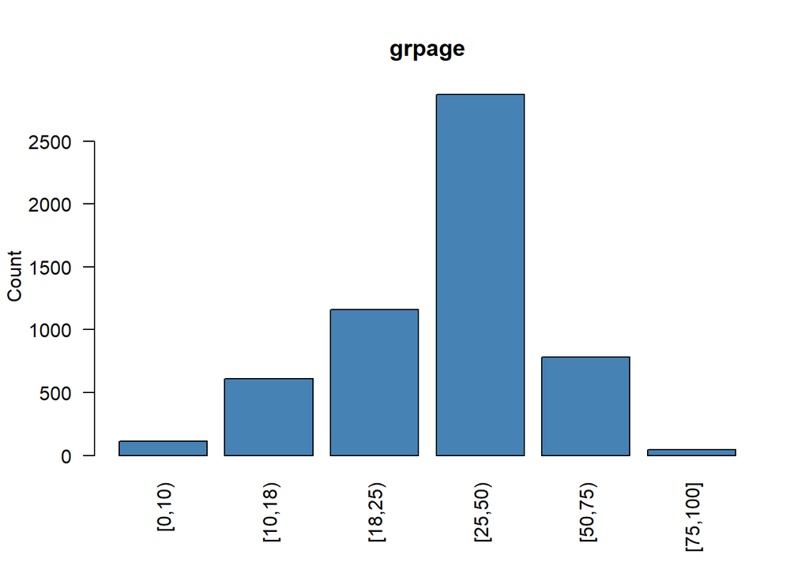

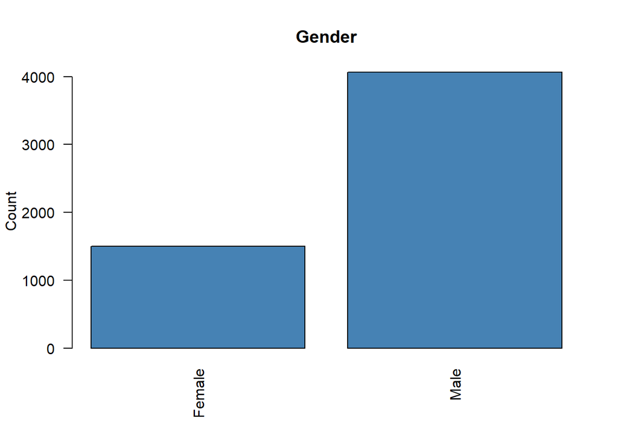

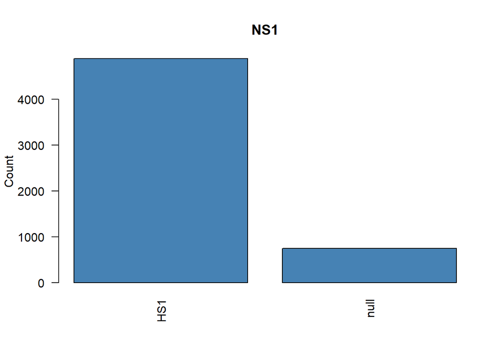

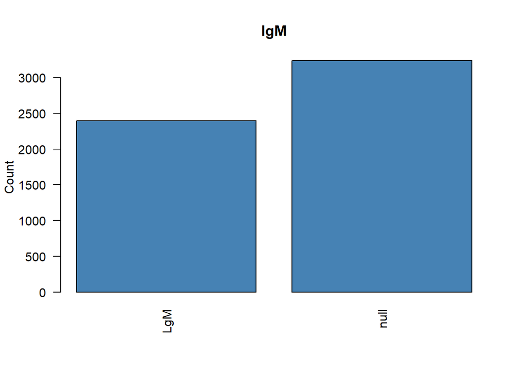

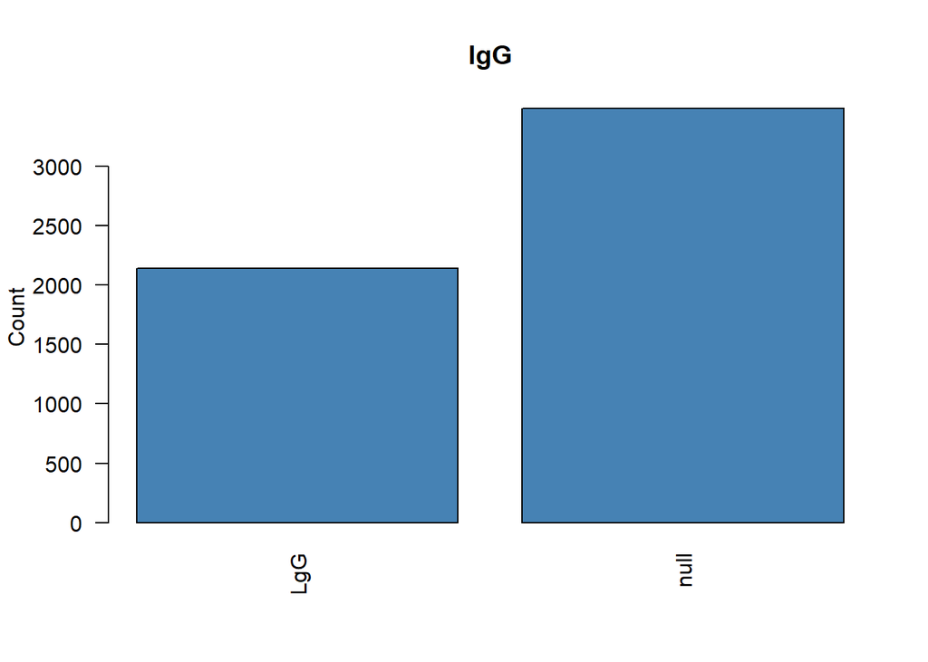

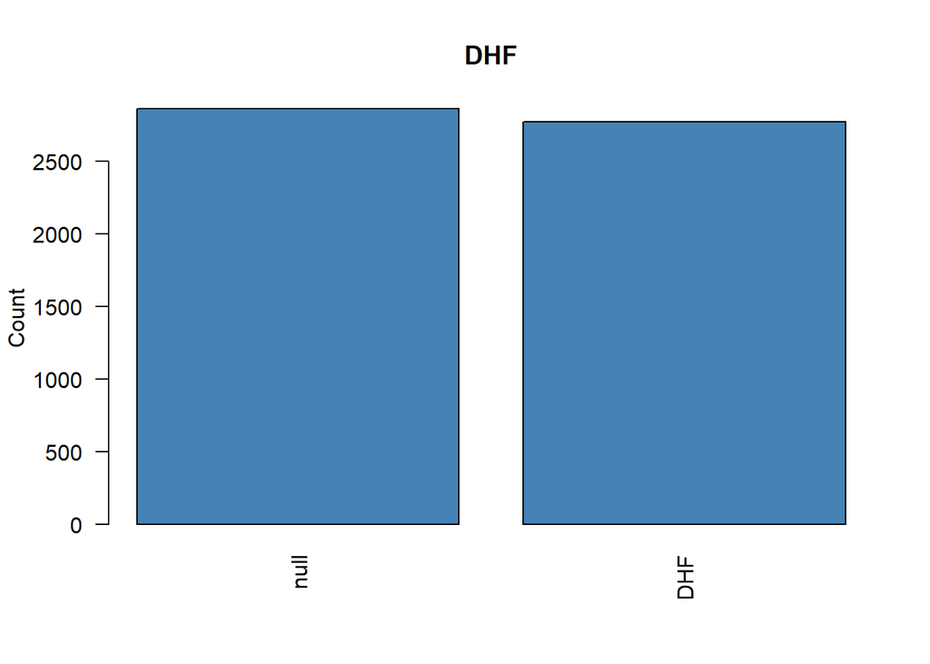

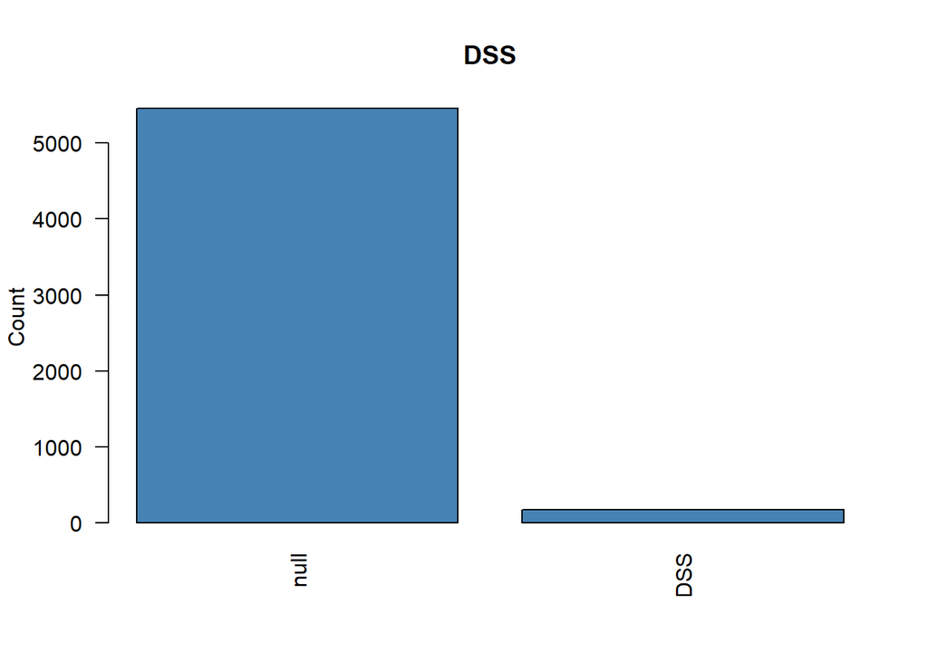

```r
Data2<-Data[,c("grpage","Gender","NS1", "IgM", "IgG", "DF","DHF", "DSS")]

# Let describe Data2

for (i in 1:8) {
  plot(Data2[,i], main=colnames(Data2)[i],
       ylab = "Count", col="steelblue", las = 2)
  }
```

[output not shown]

```r
# here i use MCA, because i have more than two categorials variables
acm2 <- MCA(Data2[complete.cases(Data2), ], ncp = 5, graph = FALSE)## removing NA data
acm2
```

```
## **Results of the Multiple Correspondence Analysis (MCA)**
## The analysis was performed on 5522 individuals, described by 8 variables
## *The results are available in the following objects:
##
##    name              description
## 1  "$eig"            "eigenvalues"
## 2  "$var"            "results for the variables"
## 3  "$var$coord"      "coord. of the categories"
## 4  "$var$cos2"       "cos2 for the categories"
## 5  "$var$contrib"    "contributions of the categories"
## 6  "$var$v.test"     "v-test for the categories"
## 7  "$ind"            "results for the individuals"
## 8  "$ind$coord"      "coord. for the individuals"
## 9  "$ind$cos2"       "cos2 for the individuals"
## 10 "$ind$contrib"    "contributions of the individuals"
## 11 "$call"           "intermediate results"
## 12 "$call$marge.col" "weights of columns"
## 13 "$call$marge.li"  "weights of rows"
```

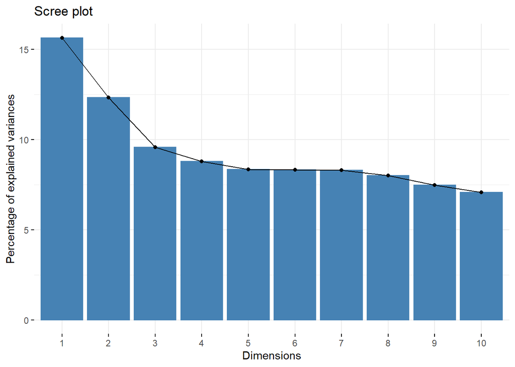

```r
fviz_screeplot(acm2)# inertie per axis
```

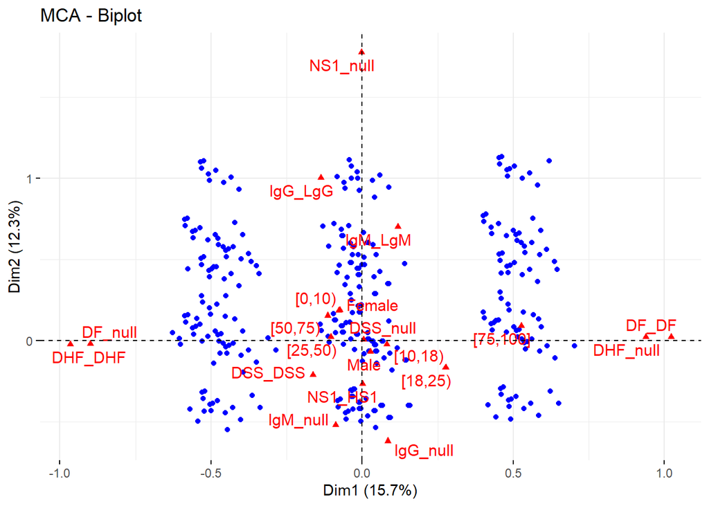

```r
fviz_mca_biplot(acm2,repel = TRUE, ggtheme = theme_minimal())## without patient with  missing data
```

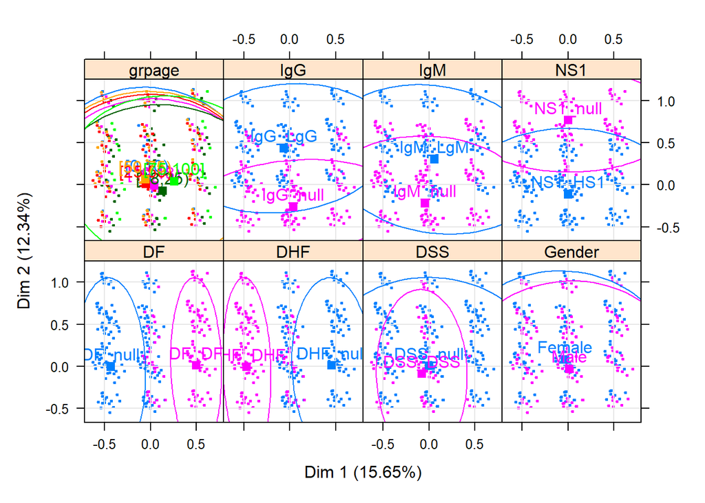

```r
plotellipses(acm2, means = FALSE)
```

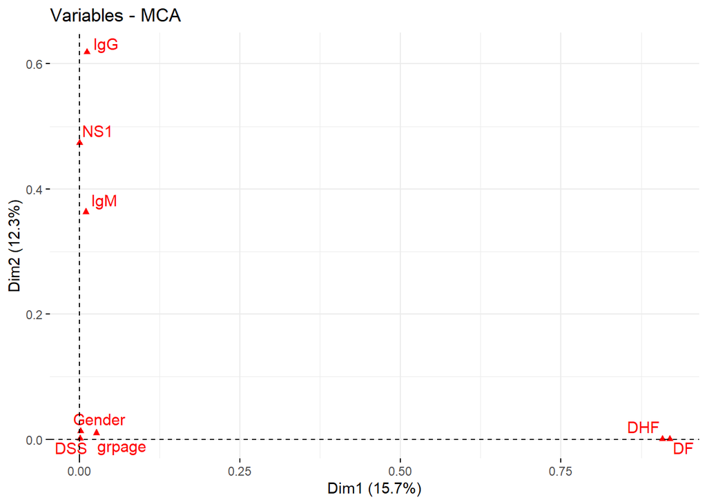

```r
fviz_mca_var(acm2, choice = "mca.cor",
            repel = TRUE, # Avoid text overlapping (slow)
            ggtheme = theme_minimal())
```

## Any association beetwen DF and symptoms?

It seems that Dengue fever is associate in negative way with having Arthralgia,Vomiting,Abdominal Pain and rash, but what is tender? I mean, cheching the barplot of sympotms columns it seems that patient with DF , are usualy with Fever and myalgia, but no significancy (with logistic regression and with chisq)???

```r
Data3=Data[,c(9,12:22)]
head(Data3)
```

| DF | Fever(>38 C) | Myalgia | Arthralgia | Erythema | Facial flushing | Retro-orbital pain | Nausea | Vomiting | Diarrhea | Abdominal Pain | Rash |
| --- | --- | --- | --- | --- | --- | --- | --- | --- | --- | --- | --- |
| null | Yes | Yes | Yes | No | No | No | No | Yes | No | Yes | No |
| DF | Yes | Yes | Yes | No | No | Yes | No | No | No | No | No |
| DF | Yes | Yes | No | No | No | No | No | No | No | No | No |
| DF | Yes | Yes | No | No | No | Yes | No | No | No | No | Yes |
| DF | Yes | No | Yes | No | No | No | No | Yes | Yes | No | No |
| null | Yes | No | Yes | No | No | Yes | No | No | No | No | No |

```r
dim(Data3)
```

```
## [1] 5633   12
```

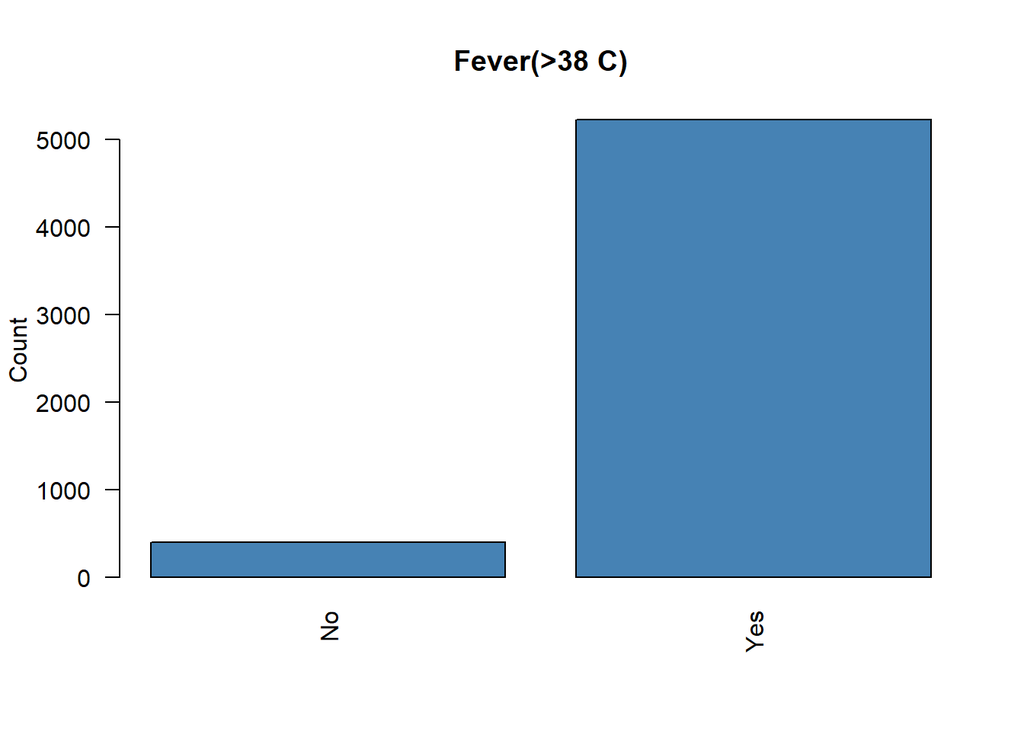

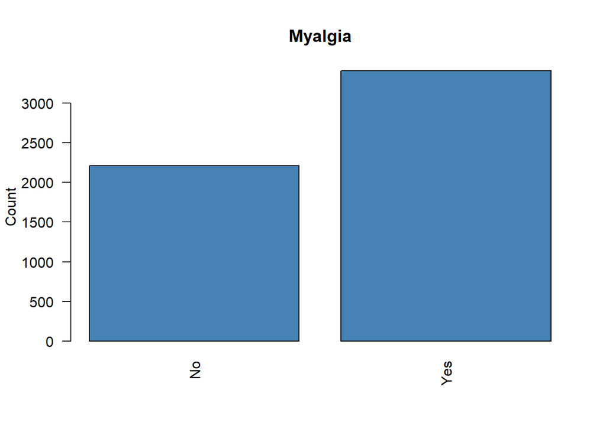

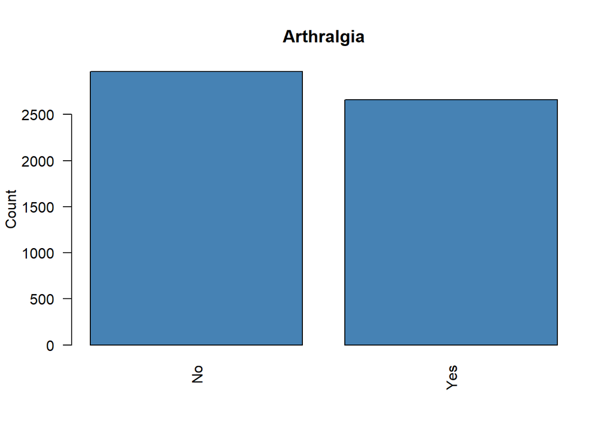

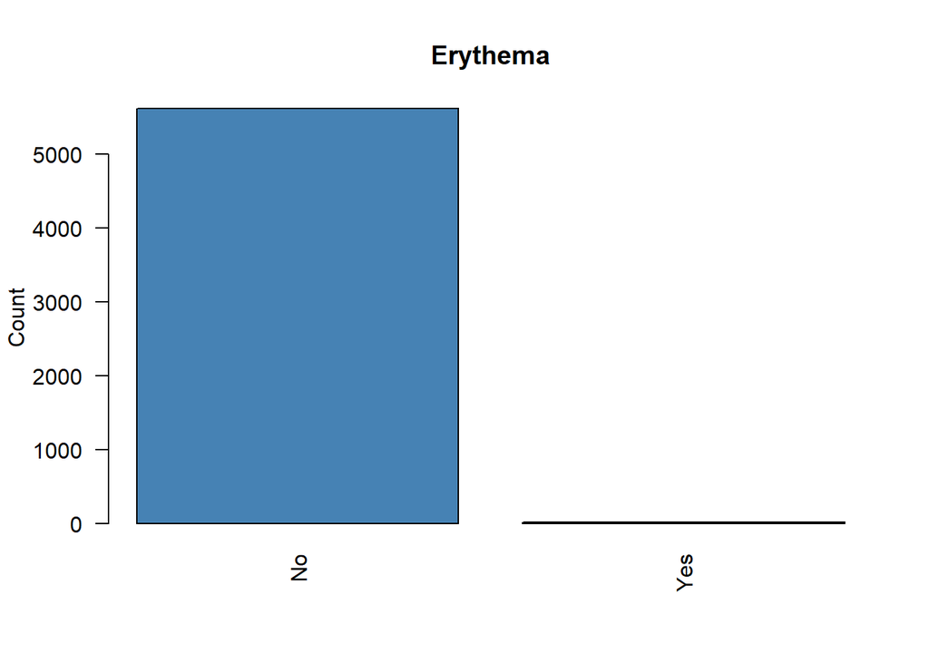

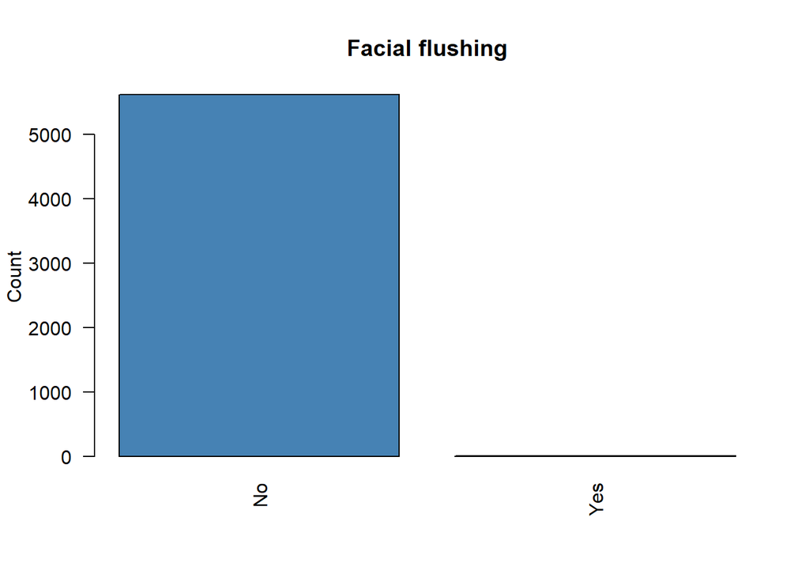

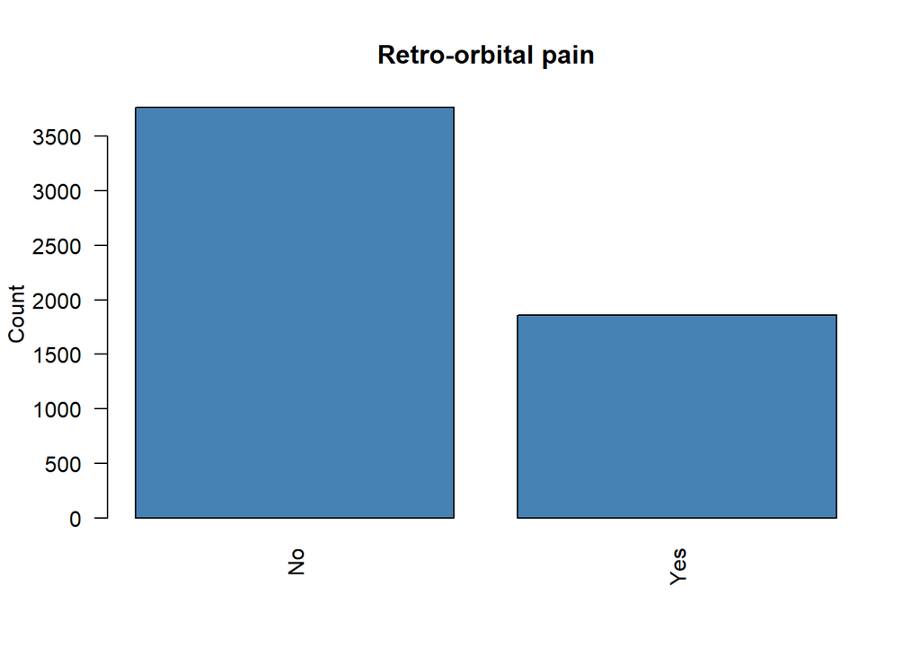

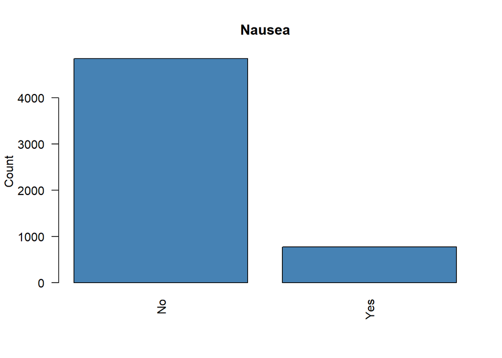

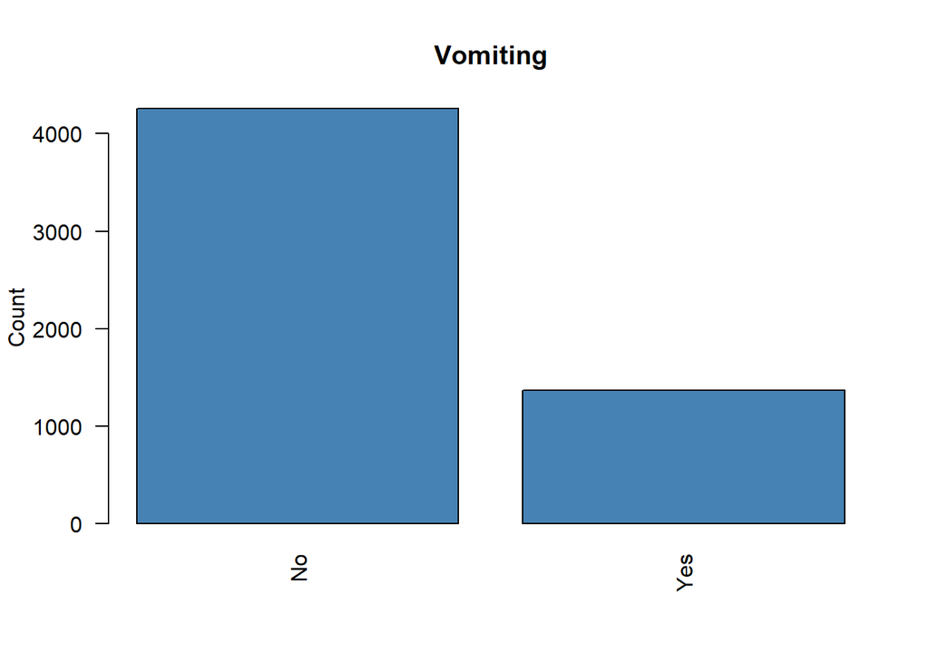

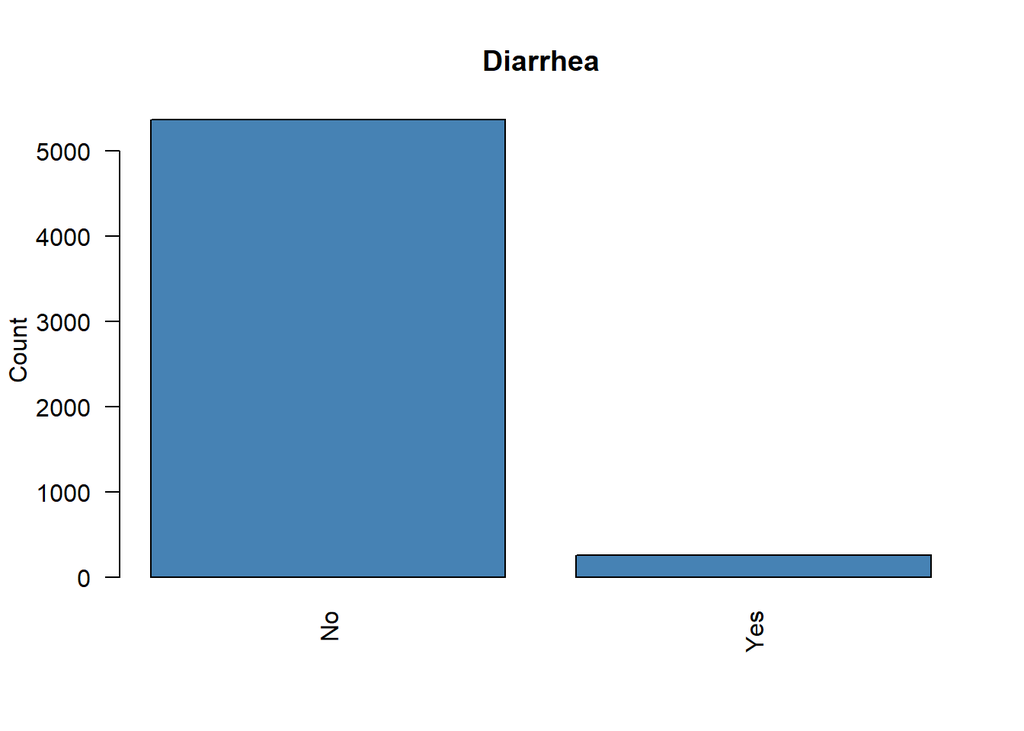

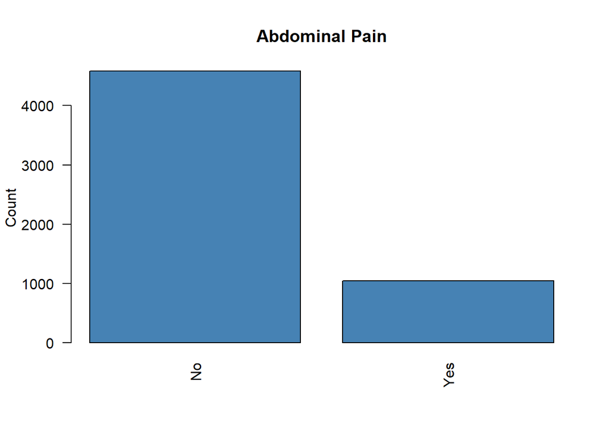

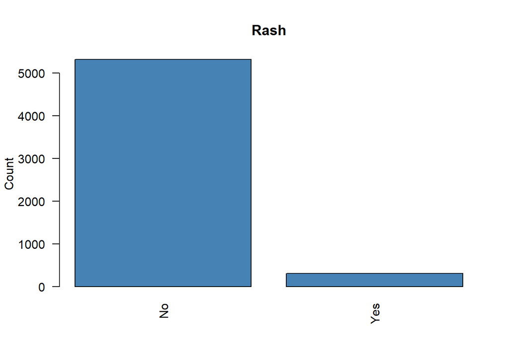

```r
# Let describe Data3

for (i in 1:12) {
  plot(Data3[,i], main=colnames(Data3)[i],
       ylab = "Count", col="steelblue", las = 2)
  }
```

```r
# MCA

Data3=Data[,c(9,12:22)]
head(Data3)
```

| DF | Fever(>38 C) | Myalgia | Arthralgia | Erythema | Facial flushing | Retro-orbital pain | Nausea | Vomiting | Diarrhea | Abdominal Pain | Rash |
| --- | --- | --- | --- | --- | --- | --- | --- | --- | --- | --- | --- |
| null | Yes | Yes | Yes | No | No | No | No | Yes | No | Yes | No |
| DF | Yes | Yes | Yes | No | No | Yes | No | No | No | No | No |
| DF | Yes | Yes | No | No | No | No | No | No | No | No | No |
| DF | Yes | Yes | No | No | No | Yes | No | No | No | No | Yes |
| DF | Yes | No | Yes | No | No | No | No | Yes | Yes | No | No |
| null | Yes | No | Yes | No | No | Yes | No | No | No | No | No |

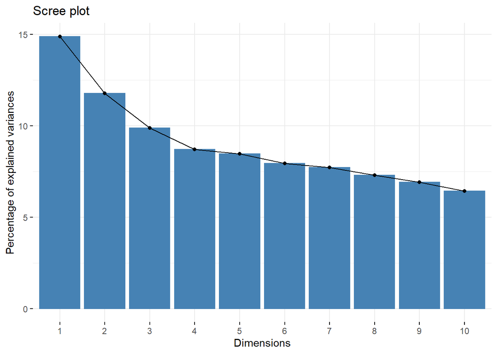

```r
acm3 <- MCA(Data3[complete.cases(Data3), ], ncp = 5, graph = FALSE)## removing NA data
fviz_screeplot(acm3)# inertie per axis
```

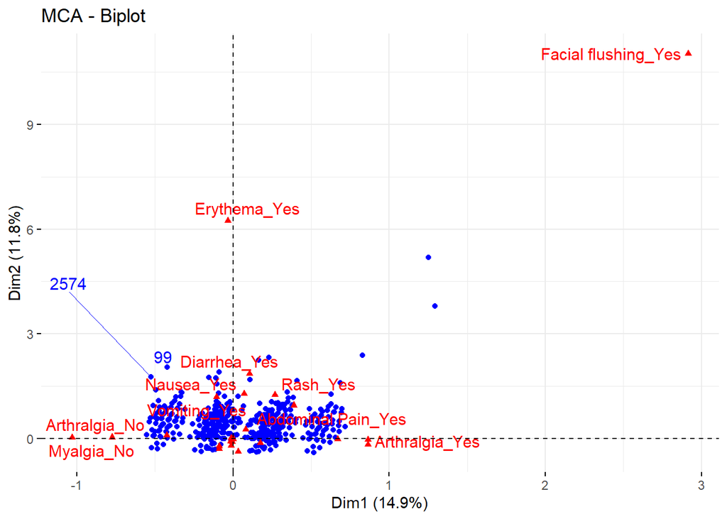

```r
fviz_mca_biplot(acm3,repel = TRUE,ggtheme = theme_minimal())
```

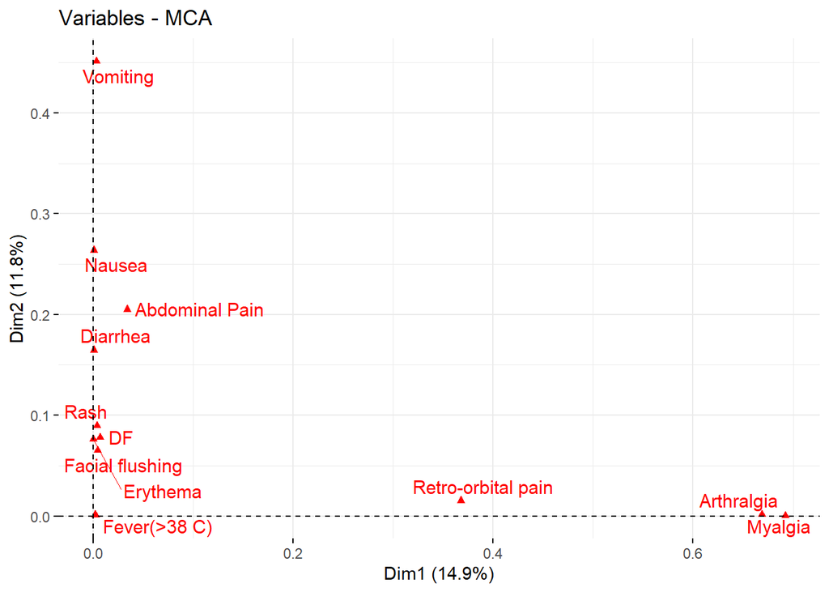

```r
fviz_mca_var(acm3, choice = "mca.cor",
            repel = TRUE, # Avoid text overlapping (slow)
            ggtheme = theme_minimal())
```

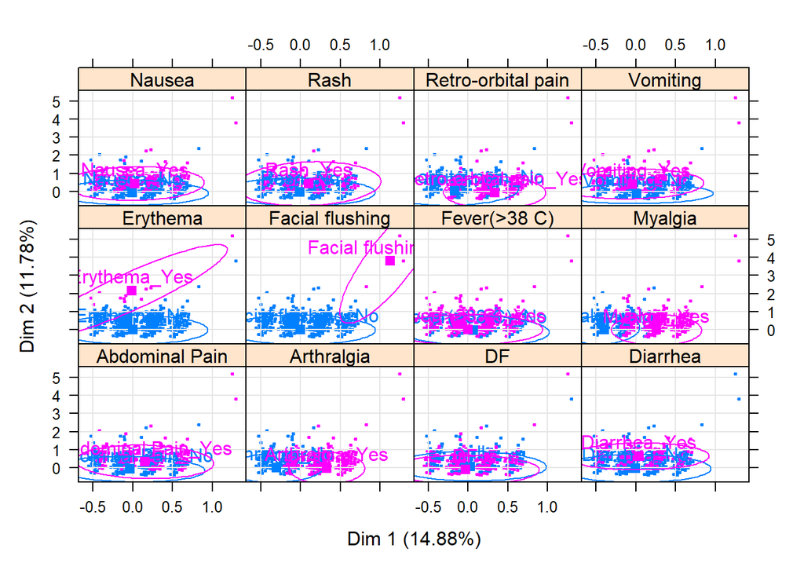

```r
plotellipses(acm3, means = FALSE)
```

```r
# logistic regression (What symptoms are associated with DF )

Data3$DF <- relevel(Data3$DF, "null")# here are use all symptoms
reg <- glm(DF ~ `Fever(>38 C)` + Myalgia+ Arthralgia+ Erythema+`Facial flushing` +`Facial flushing`+`Retro-orbital pain`+ Nausea+ Vomiting+ Diarrhea+ `Abdominal Pain` + Rash, data = Data3, family = binomial(logit))
reg
```

```
##
## Call:  glm(formula = DF ~ `Fever(>38 C)` + Myalgia + Arthralgia + Erythema +
##     `Facial flushing` + `Facial flushing` + `Retro-orbital pain` +
##     Nausea + Vomiting + Diarrhea + `Abdominal Pain` + Rash, family = binomial(logit),
##     data = Data3)
##
## Coefficients:
##             (Intercept)        `Fever(>38 C)`Yes               MyalgiaYes
##                0.096920                -0.009029                 0.044833
##           ArthralgiaYes              ErythemaYes     `Facial flushing`Yes
##               -0.208070                -0.450994                 1.301575
## `Retro-orbital pain`Yes                NauseaYes              VomitingYes
##                0.049333                -0.072159                -0.256710
##             DiarrheaYes      `Abdominal Pain`Yes                  RashYes
##               -0.250063                -0.497227                 0.243536
##
## Degrees of Freedom: 5622 Total (i.e. Null);  5611 Residual
##   (10 observations deleted due to missingness)
## Null Deviance:       7773
## Residual Deviance: 7674  AIC: 7698
```

```r
summary(reg)
```

```
##
## Call:
## glm(formula = DF ~ `Fever(>38 C)` + Myalgia + Arthralgia + Erythema +
##     `Facial flushing` + `Facial flushing` + `Retro-orbital pain` +
##     Nausea + Vomiting + Diarrhea + `Abdominal Pain` + Rash, family = binomial(logit),
##     data = Data3)
##
## Deviance Residuals:
##     Min       1Q   Median       3Q      Max
## -1.4822  -1.1456  -0.9106   1.1885   1.7091
##
## Coefficients:
##                          Estimate Std. Error z value Pr(>|z|)
## (Intercept)              0.096920   0.109870   0.882  0.37771
## `Fever(>38 C)`Yes       -0.009029   0.105404  -0.086  0.93174
## MyalgiaYes               0.044833   0.067602   0.663  0.50721
## ArthralgiaYes           -0.208070   0.065577  -3.173  0.00151 **
## ErythemaYes             -0.450994   0.655477  -0.688  0.49143
## `Facial flushing`Yes     1.301575   1.274610   1.021  0.30718
## `Retro-orbital pain`Yes  0.049333   0.060843   0.811  0.41747
## NauseaYes               -0.072159   0.080332  -0.898  0.36904
## VomitingYes             -0.256710   0.065784  -3.902 9.53e-05 ***
## DiarrheaYes             -0.250063   0.134860  -1.854  0.06370 .
## `Abdominal Pain`Yes     -0.497227   0.072072  -6.899 5.24e-12 ***
## RashYes                  0.243536   0.119976   2.030  0.04237 *
## ---
## Signif. codes:  0 '***' 0.001 '**' 0.01 '*' 0.05 '.' 0.1 ' ' 1
##
## (Dispersion parameter for binomial family taken to be 1)
##
##     Null deviance: 7773.2  on 5622  degrees of freedom
## Residual deviance: 7673.7  on 5611  degrees of freedom
##   (10 observations deleted due to missingness)
## AIC: 7697.7
##
## Number of Fisher Scoring iterations: 4
```

```r
Anova(reg)
```

|  | LR Chisq | Df | Pr(>Chisq) |
| --- | --- | --- | --- |
| `Fever(>38 C)` | 0.007336502 | 1 | 9.317420e-01 |
| Myalgia | 0.440002345 | 1 | 5.071213e-01 |
| Arthralgia | 10.081604153 | 1 | 1.497569e-03 |
| Erythema | 0.489858381 | 1 | 4.839905e-01 |
| `Facial flushing` | 1.131381345 | 1 | 2.874809e-01 |
| `Retro-orbital pain` | 0.657349649 | 1 | 4.174972e-01 |
| Nausea | 0.808161004 | 1 | 3.686645e-01 |
| Vomiting | 15.310524891 | 1 | 9.120693e-05 |
| Diarrhea | 3.487610399 | 1 | 6.182977e-02 |
| `Abdominal Pain` | 48.712040539 | 1 | 2.964409e-12 |

[output cut: 1 more lines]

```r
## # logistic regression (I use Fever and Myalgia which seems more clear with plot )

reg <- glm(DF ~ `Fever(>38 C)` + Myalgia, data = Data3, family = binomial(logit))
reg
```

```
##
## Call:  glm(formula = DF ~ `Fever(>38 C)` + Myalgia, family = binomial(logit),
##     data = Data3)
##
## Coefficients:
##       (Intercept)  `Fever(>38 C)`Yes         MyalgiaYes
##          -0.06134           -0.01665           -0.07954
##
## Degrees of Freedom: 5622 Total (i.e. Null);  5620 Residual
##   (10 observations deleted due to missingness)
## Null Deviance:       7773
## Residual Deviance: 7771  AIC: 7777
```

```r
summary(reg)
```

```
##
## Call:
## glm(formula = DF ~ `Fever(>38 C)` + Myalgia, family = binomial(logit),
##     data = Data3)
##
## Deviance Residuals:
##    Min      1Q  Median      3Q     Max
## -1.151  -1.111  -1.111   1.245   1.245
##
## Coefficients:
##                   Estimate Std. Error z value Pr(>|z|)
## (Intercept)       -0.06134    0.10599  -0.579    0.563
## `Fever(>38 C)`Yes -0.01665    0.10418  -0.160    0.873
## MyalgiaYes        -0.07954    0.05469  -1.455    0.146
##
## (Dispersion parameter for binomial family taken to be 1)
##
##     Null deviance: 7773.2  on 5622  degrees of freedom
## Residual deviance: 7771.1  on 5620  degrees of freedom
##   (10 observations deleted due to missingness)
## AIC: 7777.1
##
## Number of Fisher Scoring iterations: 3
```

```r
Anova(reg)
```

|  | LR Chisq | Df | Pr(>Chisq) |
| --- | --- | --- | --- |
| `Fever(>38 C)` | 0.02554401 | 1 | 0.8730190 |
| Myalgia | 2.11540875 | 1 | 0.1458231 |

```r
# Chisq to check any association beetwen Fever and DF
round((table(Data3$DF,Data3$`Fever(>38 C)`)/5980)*100,2)# percentage
```

```
##
##           No   Yes
##   null  3.51 46.44
##   DF    3.14 40.94
```

```r
chisq.test(table(Data3$DF,Data3$`Fever(>38 C)`))
```

```
##
##  Pearson's Chi-squared test with Yates' continuity correction
##
## data:  table(Data3$DF, Data3$`Fever(>38 C)`)
## X-squared = 0.0092306, df = 1, p-value = 0.9235
```